# Analyzing Individual BGG Users

Phil Henrickson

2022-01-01

# **jjmarlette’s** BoardGameGeek Collection

This notebook contains a set of analyses for the selected user’s boardgamegeek collection. The bulk of the analysis is focused on building a user-specific predictive model to predict the games that jjmarlette is likely to own. This enables to ask questions like, based on the games the user currently owns, what games are a good fit for their collection? What upcoming games are they likely to purchase?

This analysis is based on data from BoardGameGeek that was last updated on **2021-12-20.**

# 1 Collection Overview

We can look at a basic description of the number of games that the user owns, has rated, has previously owned, etc.

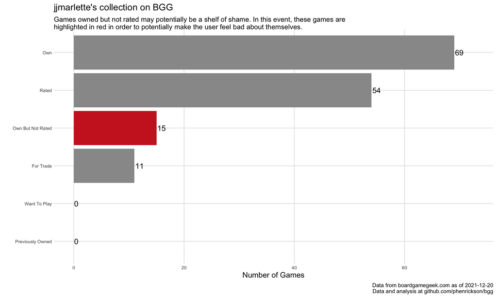

What years has the user owned/rated games from? While we can’t see when a user added or removed a game from their collection, we can look at their collection by the years in which their games were published.

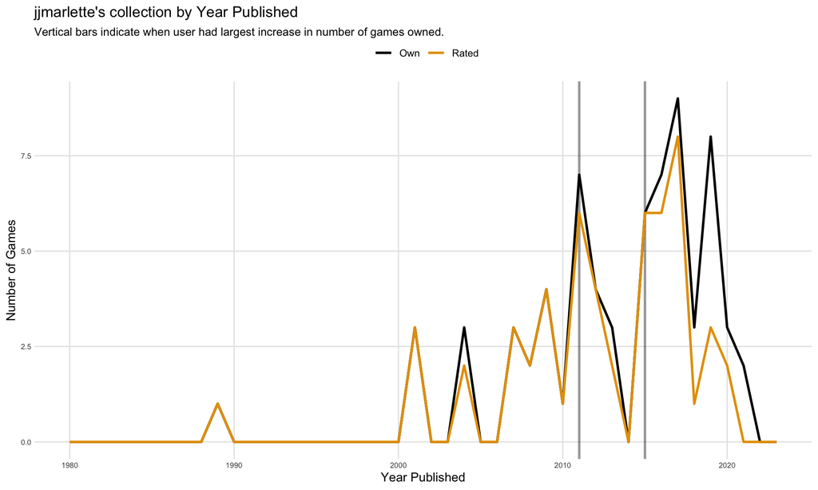

## 1.1 What types of games does jjmarlette own?

We can look at the most frequent types of categories, mechanics, designers, and artists that appear in a user’s collection.

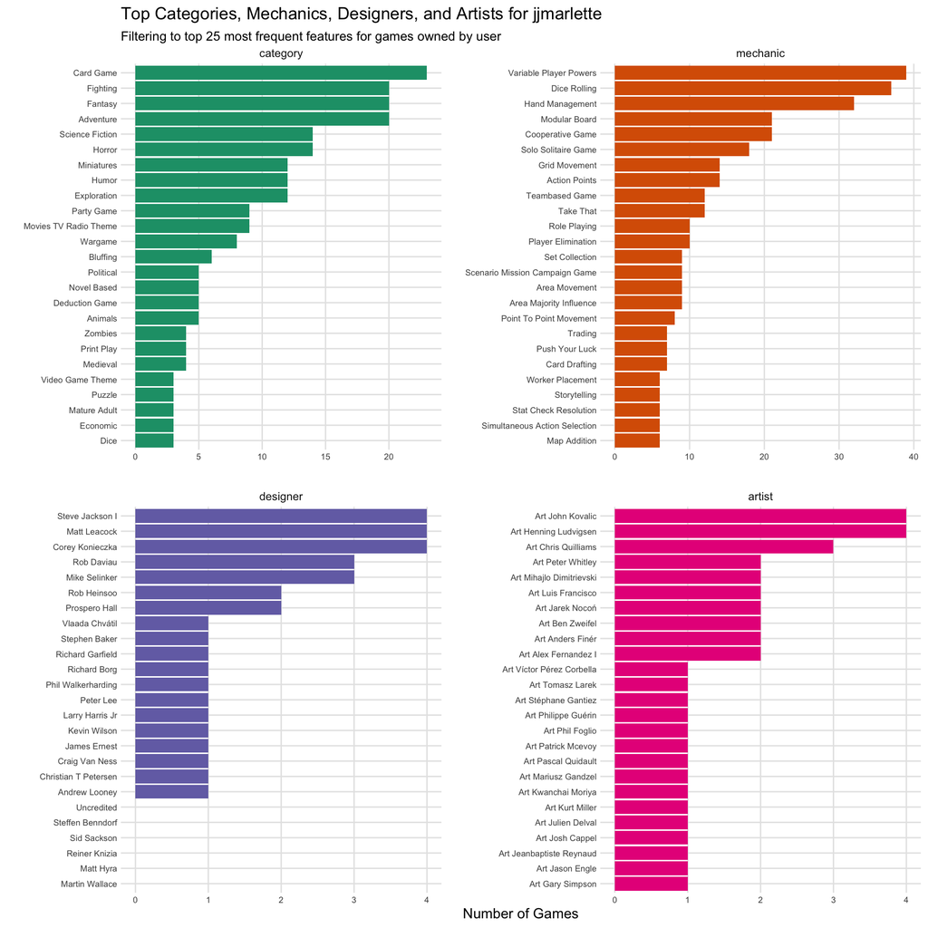

# 2 Modeling **jjmarlette’s** Collection

| username | dataset | period | games_owned | games_rated | games_played |
| --- | --- | --- | --- | --- | --- |
| jjmarlette | training | published before 2020 | 62 | 50 | 62 |
| jjmarlette | test | published 2020 or later | 5 | 2 | 5 |

There are two main (binary) outcomes we will be modeling for the user.

The first, **own** refers to whether the user currently lists a game as owned in their collection. The second, **played** refers to whether the user currently owns, has rated, or previously owned a game. This means the latter will generally have a larger list of games, but may still be a useful category to examine for people who play lots of games without necessarily owning them.

We will train predictive models to learn the probability that the user will own or play individual games based on their features.

## 2.1 Coefficients for jjmarlette

We can examine coefficients from the trained modes, which are penalized logistic regressions fit to our two main outcomes. Positive values indicate that a feature increases a user’s probabilility of owning/rating a game, while negative values indicate a feature decreases the probability.

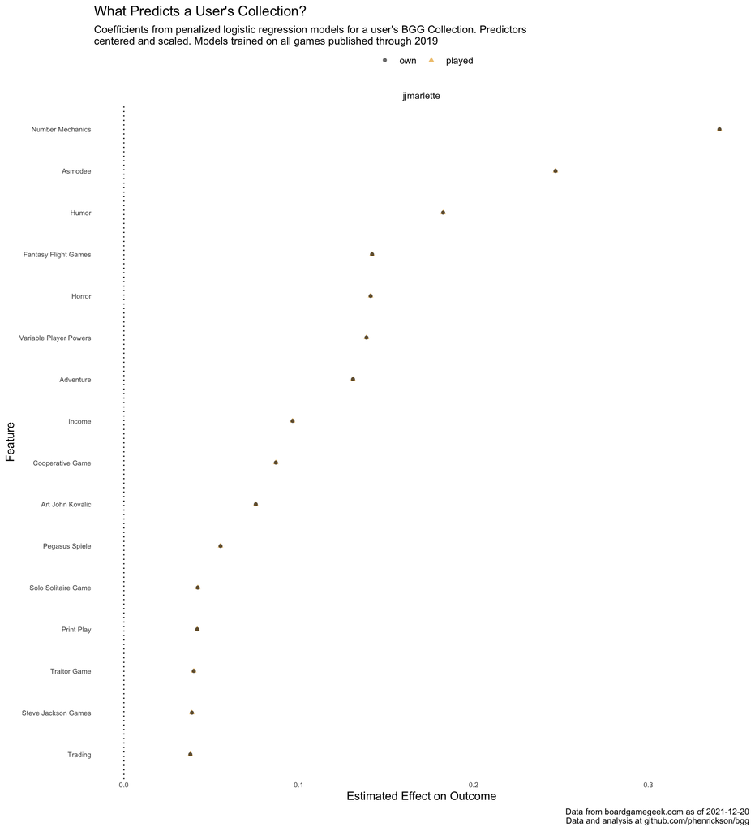

## 2.2 Visualizing Predictors for jjmarlette’s Collection

Why did the model identify these features? We can make density plots of the important features for predicting whether the user owned a game. Blue indicates the density for games owned by the user, while grey indicates the density for games not owned by the user.

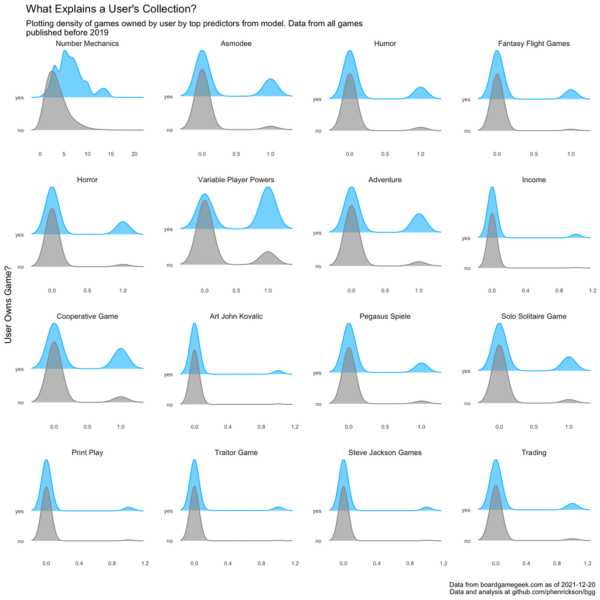

Binary predictors can be difficult to see with this visualization, so we can also directly examine the percentage of games in a user’s collection with a predictor vs the percentage of all games with that predictor.

| username | Feature | % of Games with Feature In_Collection | % of Games with Feature All_Games | Ratio |
| --- | --- | --- | --- | --- |
| jjmarlette | Traitor Game | 6.5% | 0.6% | 10.1 |
| jjmarlette | Income | 6.5% | 0.7% | 9.3 |
| jjmarlette | Hidden Roles | 4.8% | 0.7% | 6.9 |
| jjmarlette | Fantasy Flight Games | 16.1% | 2.5% | 6.3 |
| jjmarlette | Steve Jackson Games | 6.5% | 1.0% | 6.2 |
| jjmarlette | CMON Global Limited | 4.8% | 0.8% | 6.0 |
| jjmarlette | Horror | 21.0% | 3.8% | 5.5 |
| jjmarlette | Asmodee | 27.4% | 5.2% | 5.2 |
| jjmarlette | Adventure | 29.0% | 6.5% | 4.5 |
| jjmarlette | Solo Solitaire Game | 22.6% | 5.8% | 3.9 |
| jjmarlette | Player Elimination | 14.5% | 4.0% | 3.7 |
| jjmarlette | Cooperative Game | 30.6% | 8.4% | 3.6 |
| jjmarlette | Trading | 11.3% | 3.2% | 3.6 |
| jjmarlette | Humor | 19.4% | 5.5% | 3.5 |
| jjmarlette | Pegasus Spiele | 16.1% | 4.7% | 3.4 |
| jjmarlette | Print Play | 6.5% | 1.9% | 3.4 |
| jjmarlette | Variable Player Powers | 54.8% | 16.8% | 3.3 |
| jjmarlette | Fighting | 29.0% | 9.0% | 3.2 |
| jjmarlette | Teambased Game | 19.4% | 6.3% | 3.1 |
| jjmarlette | Take That | 17.7% | 6.6% | 2.7 |
| jjmarlette | Hand Management | 46.8% | 26.6% | 1.8 |
| jjmarlette | Word Game | 1.6% | 1.8% | 0.9 |
| jjmarlette | Negotiation | 3.2% | 3.7% | 0.9 |
| jjmarlette | Events | 0.0% | 2.0% | 0.0 |
| jjmarlette | Trivia | 0.0% | 1.8% | 0.0 |

# 3 Assess Model’s Performance on Training Set

Before predicting games in upcoming years, we can examine how well the model did and what games it liked in the training set. In this case, we used resampling techniques (cross validation) to ensure that the model had not seen a game before making its predictions.

## 3.1 Separation Plot

An easy way to examine the performance of classification model is to view a separation plot. We plot the predicted probabilities from the model for every game (from resampling) from lowest to highest. We then overlay a blue line for any game that the user does own. A good classifier is one that is able to *separate* the blue (games owned by the user) from the white (games not owned by the user), with most of the blue occurring at the highest probabilities (right side of the chart).

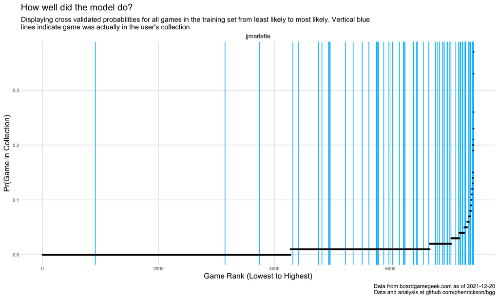

## 3.2 Top Games for **jjmarlette** from Training Set

We can display this information in table form, displaying the 100 games with the highest probability of ownership, adding a blue line when the user does own the game.

| username | yearpublished | game_id | name | pred_played | pred_own | actual_played | actual_own |
| --- | --- | --- | --- | --- | --- | --- | --- |
| jjmarlette | 2017 | 174430 | Gloomhaven | 0.37 | 0.37 | 0 | 0 |
| jjmarlette | 2018 | 257499 | Arkham Horror (Third Edition) | 0.33 | 0.33 | 0 | 0 |
| jjmarlette | 2016 | 205059 | Mansions of Madness: Second Edition | 0.26 | 0.26 | 1 | 1 |
| jjmarlette | 2008 | 37111 | Battlestar Galactica: The Board Game | 0.23 | 0.23 | 0 | 0 |
| jjmarlette | 2012 | 113924 | Zombicide | 0.23 | 0.23 | 0 | 0 |
| jjmarlette | 2016 | 205716 | New Angeles | 0.21 | 0.21 | 0 | 0 |
| jjmarlette | 2011 | 96848 | Mage Knight Board Game | 0.20 | 0.20 | 0 | 0 |
| jjmarlette | 2005 | 15987 | Arkham Horror | 0.20 | 0.20 | 0 | 0 |
| jjmarlette | 2017 | 188920 | This War of Mine: The Board Game | 0.20 | 0.20 | 0 | 0 |
| jjmarlette | 2019 | 269385 | The Lord of the Rings: Journeys in Middle-Earth | 0.20 | 0.20 | 1 | 1 |
| jjmarlette | 2018 | 167355 | Nemesis | 0.19 | 0.19 | 0 | 0 |
| jjmarlette | 2004 | 12194 | Munchkin Bites! | 0.15 | 0.15 | 0 | 0 |
| jjmarlette | 2018 | 224710 | Zombicide: Green Horde | 0.15 | 0.15 | 0 | 0 |
| jjmarlette | 2014 | 146652 | Legendary Encounters: An Alien Deck Building Game | 0.15 | 0.15 | 0 | 0 |
| jjmarlette | 2016 | 176083 | Hit Z Road | 0.14 | 0.14 | 0 | 0 |
| jjmarlette | 2018 | 254591 | Heroes of Terrinoth | 0.14 | 0.14 | 0 | 0 |
| jjmarlette | 2006 | 14808 | Marvel Heroes | 0.14 | 0.14 | 0 | 0 |
| jjmarlette | 2019 | 266507 | Clank!: Legacy – Acquisitions Incorporated | 0.13 | 0.13 | 0 | 0 |
| jjmarlette | 2012 | 104162 | Descent: Journeys in the Dark (Second Edition) | 0.13 | 0.13 | 1 | 1 |
| jjmarlette | 2012 | 121921 | Robinson Crusoe: Adventures on the Cursed Island | 0.12 | 0.12 | 0 | 0 |
| jjmarlette | 2019 | 264220 | Tainted Grail: The Fall of Avalon | 0.12 | 0.12 | 0 | 0 |
| jjmarlette | 2019 | 276025 | Maracaibo | 0.12 | 0.12 | 0 | 0 |
| jjmarlette | 2006 | 23142 | Mag·Blast: Third Edition | 0.12 | 0.12 | 0 | 0 |
| jjmarlette | 2015 | 161866 | Zombicide Season 3: Rue Morgue | 0.12 | 0.12 | 0 | 0 |
| jjmarlette | 2005 | 18723 | Aye, Dark Overlord! The Red Box | 0.12 | 0.12 | 0 | 0 |
| jjmarlette | 1986 | 925 | Werewolf | 0.12 | 0.12 | 0 | 0 |
| jjmarlette | 2016 | 204837 | Game of Thrones: The Iron Throne | 0.12 | 0.12 | 0 | 0 |
| jjmarlette | 2018 | 205896 | Rising Sun | 0.12 | 0.12 | 0 | 0 |
| jjmarlette | 2009 | 36932 | Claustrophobia | 0.11 | 0.11 | 0 | 0 |
| jjmarlette | 1995 | 13 | Catan | 0.11 | 0.11 | 0 | 0 |

[output cut: 70 more lines]

We can also more formally assess how well the model did in resampling by looking at the area under the receiver operating characteristic. A perfect model would receive a score of 1, while a model that cannot predict the outcome will default to a score of 0.5. The extent to which something is a *good* score depends on the setting, but generally anything in the .8 to .9 range is very good while the .7 to .8 range is perfectly acceptable.

| username | outcome_type | .metric | .estimator | .estimate |
| --- | --- | --- | --- | --- |
| jjmarlette | own | roc_auc | binary | 0.839 |
| jjmarlette | played | roc_auc | binary | 0.839 |

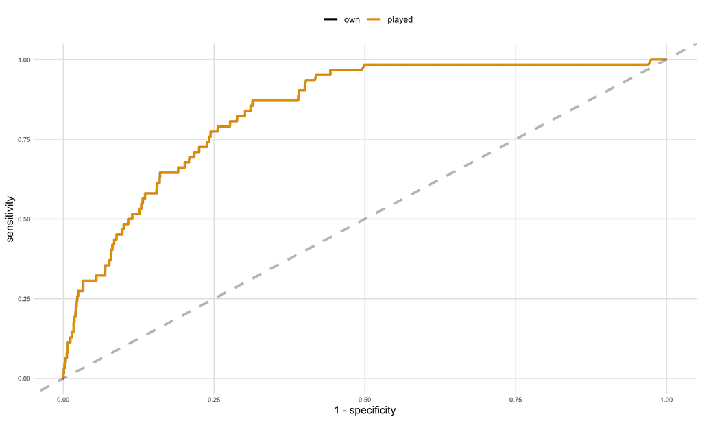

Another way to think about the model performance is to view its lift, or its ability to detect the positive outcomes over that of a null model. High lift indicates the model can much more quickly find all of the positive outcomes (in this case, games owned or played by the user), while a model with no lift is no better than random guessing.

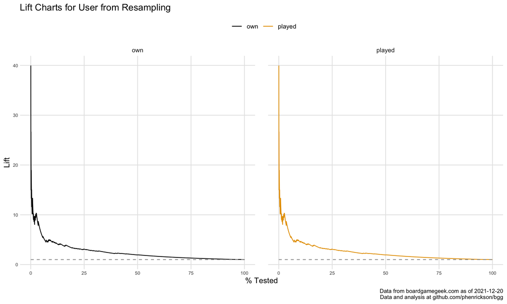

## 3.3 Most and Least Likely Games

What games does the model think jjmarlette is **most likely to own** that are **not** in their collection?

| username | yearpublished | game_id | name | pred_own | actual_own |
| --- | --- | --- | --- | --- | --- |
| jjmarlette | 2017 | 174430 | Gloomhaven | 0.37 | 0 |
| jjmarlette | 2018 | 257499 | Arkham Horror (Third Edition) | 0.33 | 0 |
| jjmarlette | 2008 | 37111 | Battlestar Galactica: The Board Game | 0.23 | 0 |
| jjmarlette | 2012 | 113924 | Zombicide | 0.23 | 0 |
| jjmarlette | 2016 | 205716 | New Angeles | 0.21 | 0 |

What games does the model think jjmarlette is **least likely to own** that **are** in their collection?

| username | yearpublished | game_id | name | pred_own | actual_own |
| --- | --- | --- | --- | --- | --- |
| jjmarlette | 2015 | 170042 | Raiders of the North Sea | 0.00 | 1 |
| jjmarlette | 2017 | 235365 | Doctor Who Fluxx | 0.00 | 1 |
| jjmarlette | 2004 | 10093 | Axis & Allies | 0.00 | 1 |
| jjmarlette | 2018 | 233571 | Star Wars: Legion | 0.01 | 1 |
| jjmarlette | 2016 | 179275 | One Deck Dungeon | 0.01 | 1 |

## 3.4 Top Games by Year

Top 25 games most likely to be owned by the user in each year, highlighting in blue the games that the user has owned/played.

| rank | 2011 | 2012 | 2013 | 2014 | 2015 | 2016 | 2017 | 2018 | 2019 |
| --- | --- | --- | --- | --- | --- | --- | --- | --- | --- |
| 1 | Mage Knight Board Game | Zombicide | The Doom That Came to Atlantic City | Legendary Encounters: An Alien Deck Building Game | Zombicide Season 3: Rue Morgue | Mansions of Madness: Second Edition | Gloomhaven | Arkham Horror (Third Edition) | The Lord of the Rings: Journeys in Middle-Earth |
| 2 | Elder Sign | Descent: Journeys in the Dark (Second Edition) | BANG! The Dice Game | Patchwork | Warhammer Quest: The Adventure Card Game | New Angeles | This War of Mine: The Board Game | Nemesis | Clank!: Legacy – Acquisitions Incorporated |
| 3 | Mansions of Madness | Robinson Crusoe: Adventures on the Cursed Island | Munchkin Pathfinder | Star Wars: Imperial Assault | Zombicide: Black Plague | Hit Z Road | Fallout | Zombicide: Green Horde | Tainted Grail: The Fall of Avalon |
| 4 | Dungeon Fighter | Munchkin Conan | Ultimate Werewolf: Inquisition | DungeonQuest Revised Edition | One Night Ultimate Werewolf: Daybreak | Game of Thrones: The Iron Throne | Pendragon: The Fall of Roman Britain | Heroes of Terrinoth | Maracaibo |
| 5 | Takenoko | Space Cadets | Munchkin Legends | Dead of Winter: A Crossroads Game | Munchkin Oz | Citadels | Arkham Noir: Case #1 – The Witch Cult Murders | Rising Sun | Zona: The Secret of Chernobyl |
| 6 | Munchkin Zombies | Terra Mystica | Eldritch Horror | Assault on Doomrock | A Study in Emerald (Second Edition) | The Others | Summit: The Board Game | Betrayal Legacy | Tapestry |
| 7 | Flash Point: Fire Rescue | Love Letter | Super Fantasy: Ugly Snouts Assault | Ultimate Werewolf | Exploding Kittens | Terraforming Mars | Apocrypha Adventure Card Game: Box One – The World | Duelosaur Island | Star Wars: Outer Rim |
| 8 | Munchkin Axe Cop | Archipelago | Room 25 | One Night Ultimate Werewolf | Blood Rage | Bloodborne: The Card Game | Massive Darkness | The World of SMOG: Rise of Moloch | The Magnificent |
| 9 | Gears of War: The Board Game | Smash Up | Forbidden Desert | La Granja | Risk: Europe | Pandemic: Reign of Cthulhu | Folklore: The Affliction | The Order of Vampire Hunters | Barrage |
| 10 | A Game of Thrones: The Board Game (Second Edition) | Pax Porfiriana | Smash Up: Awesome Level 9000 | Spurs: A Tale in the Old West | Super Dungeon Explore: Forgotten King | The Networks | Twilight Imperium: Fourth Edition | Underwater Cities | Spire's End |
| 11 | The Adventurers: The Pyramid of Horus | Mice and Mystics | Huida de Silver City | Smash Up: Science Fiction Double Feature | T.I.M.E Stories | Black Orchestra | The Godfather: Corleone's Empire | Street Masters | Last Bastion |
| 12 | Eclipse | Legends of Andor | Blood Bound | Arcadia Quest | Kingdom Death: Monster | Dead of Winter: The Long Night | First Martians: Adventures on the Red Planet | The Pirate Republic | Paranormal Detectives |
| 13 | Rumble in the House | The Last Banquet | Spyrium | Shadows of Malice | Runebound (Third Edition) | Mistfall: Heart of the Mists | Pandemic Legacy: Season 2 | Tiny Epic Zombies | The Isle of Cats |
| 14 | Dungeons & Dragons: Wrath of Ashardalon Board Game | City of Horror | Lewis & Clark: The Expedition | Deception: Murder in Hong Kong | Argonauts | DOOM: The Board Game | Too Many Bones | Lords of Hellas | Era: Medieval Age |
| 15 | Dungeons & Dragons: The Legend of Drizzt Board Game | Rex: Final Days of an Empire | Smash Up: The Obligatory Cthulhu Set | Sons of Anarchy: Men of Mayhem | Smash Up: Munchkin | Vast: The Crystal Caverns | Betrayal at Baldur's Gate | Stuffed Fables | Day Night Z |
| 16 | A Few Acres of Snow | Serenissima (Second Edition) | Pathfinder Adventure Card Game: Rise of the Runelords – Base Set | Shadows of Brimstone: Swamps of Death | The Voyages of Marco Polo | Aventuria: Adventure Card Game | Exploding Kittens: Party Pack | The Faceless | Comanauts |
| 17 | Ascension: Return of the Fallen | Darkest Night | Train Heist | Five Tribes | Aye, Dark Overlord! The Green Box | Aeon's End | Raxxon | Western Legends | Arena: The Contest |
| 18 | Cave Evil | Munchkin Apocalypse | Firefly: The Game | Machina Arcana | Grimslingers | Crazy Karts | Rail Raiders Infinite | Deep Madness | Zombicide: Invader |
| 19 | Discworld: Ankh-Morpork | Dixit: Journey | The Hobbit: An Unexpected Journey | Run, Fight, or Die! | One Night Ultimate Vampire | Conan | Civilization: A New Dawn | Darkest Night (Second Edition) | Zombicide: Dark Side |
| 20 | Rune Age | Dixit Jinx | Patchistory | The Witcher Adventure Game | Fireteam Zero | Dawn of the Zeds (Third Edition) | Breaking Bad: The Board Game | Pandemic: Fall of Rome | Tiny Towns |
| 21 | Resident Evil Deck Building Game: Alliance | The Resistance: Avalon | Level 7 [Omega Protocol] | Spyfall | Burgle Bros. | Smash Up: It's Your Fault! | Magic Maze | Cosmic Encounter: 42nd Anniversary Edition | Wacky Races: The Board Game |
| 22 | Blood Bowl: Team Manager – The Card Game | Mage Wars Arena | Zombicide Season 2: Prison Outbreak | Stay Away! | The Pursuit of Happiness | Harry Potter: Hogwarts Battle | Muse | Too Many Bones: Undertow | Middara: Unintentional Malum – Act 1 |
| 23 | Fortune and Glory: The Cliffhanger Game | Star Trek Deck Building Game: The Next Generation – Next Phase | Impulse | Hyperborea | XCOM: The Board Game | Pathfinder Adventure Card Game: Mummy's Mask – Base Set | Rum & Bones: Second Tide | Unbroken | Arkham Horror: Final Hour |
| 24 | Ultimate Warriorz | War of the Ring: Second Edition | Friese's Landlord | Colt Express | Mysterium | Agricola (Revised Edition) | Sub Terra | Gen7: A Crossroads Game | Machina Arcana (Second/Third Edition) |
| 25 | Dixit: Odyssey | Wiz-War (Eighth Edition) | Dark Darker Darkest | Munchkin Adventure Time | Watson & Holmes | Salvation Road | Sword & Sorcery | Champions of Hara | Black Angel |

## 3.5 Interactive Predictions from Resampling

Interactive table for predictions from resampling.

|  | username | yearpublished | rank | game_id | name | pred_played | pred_own | actual_played | actual_own |
| --- | --- | --- | --- | --- | --- | --- | --- | --- | --- |
| 1 | jjmarlette | 1900 | 632 | 15878 | Rummy | 0.02 | 0.02 | 0 | 0 |
| 2 | jjmarlette | 1900 | 648 | 45 | Perudo | 0.02 | 0.02 | 0 | 0 |
| 3 | jjmarlette | 1900 | 820 | 171 | Chess | 0.01 | 0.01 | 0 | 0 |
| 4 | jjmarlette | 1900 | 824 | 2065 | Shogi | 0.01 | 0.01 | 0 | 0 |
| 5 | jjmarlette | 1900 | 920 | 2389 | Othello | 0.01 | 0.01 | 0 | 0 |
| 6 | jjmarlette | 1900 | 921 | 2397 | Backgammon | 0.01 | 0.01 | 0 | 0 |
| 7 | jjmarlette | 1900 | 1024 | 2932 | Hnefatafl | 0.01 | 0.01 | 0 | 0 |
| 8 | jjmarlette | 1900 | 1027 | 10213 | Fox and Geese | 0.01 | 0.01 | 0 | 0 |
| 9 | jjmarlette | 1900 | 1652 | 521 | Crokinole | 0.01 | 0.01 | 0 | 0 |
| 10 | jjmarlette | 1900 | 1768 | 2093 | Mahjong | 0.01 | 0.01 | 0 | 0 |

[output cut: 7426 more lines]

# 4 Validating the Model on 2020

How well did a model trained on a user’s collection through 2019 perform in predicting games for the user from 2020?

| username | outcome_type | yearpublished | .metric | .estimator | .estimate |
| --- | --- | --- | --- | --- | --- |
| jjmarlette | own | 2020 | roc_auc | binary | 0.85 |
| jjmarlette | played | 2020 | roc_auc | binary | 0.85 |

Table of top 25 games from 2020, highlighting games that the user owns.

| username | yearpublished | game_id | name | pred_own | pred_played | actual_own | actual_played |
| --- | --- | --- | --- | --- | --- | --- | --- |
| jjmarlette | 2020 | 291457 | Gloomhaven: Jaws of the Lion | 0.27 | 0.27 | 0 | 0 |
| jjmarlette | 2020 | 256317 | Guild Master | 0.12 | 0.12 | 0 | 0 |
| jjmarlette | 2020 | 304434 | Victim: The Cursed Forest | 0.11 | 0.11 | 0 | 0 |
| jjmarlette | 2020 | 246900 | Eclipse: Second Dawn for the Galaxy | 0.10 | 0.10 | 0 | 0 |
| jjmarlette | 2020 | 184267 | On Mars | 0.09 | 0.09 | 0 | 0 |
| jjmarlette | 2020 | 282922 | Windward | 0.07 | 0.07 | 0 | 0 |
| jjmarlette | 2020 | 292333 | Cowboys II: Cowboys & Indians Edition | 0.07 | 0.07 | 0 | 0 |
| jjmarlette | 2020 | 307191 | Four against the Great Old Ones | 0.07 | 0.07 | 0 | 0 |
| jjmarlette | 2020 | 310442 | Feierabend | 0.06 | 0.06 | 0 | 0 |
| jjmarlette | 2020 | 298572 | Cosmic Encounter Duel | 0.05 | 0.05 | 0 | 0 |
| jjmarlette | 2020 | 236861 | Full Moon Jacket | 0.04 | 0.04 | 0 | 0 |
| jjmarlette | 2020 | 262274 | D6: Dungeons, Dudes, Dames, Danger, Dice and Dragons! | 0.04 | 0.04 | 0 | 0 |
| jjmarlette | 2020 | 273933 | Techlandia | 0.04 | 0.04 | 0 | 0 |
| jjmarlette | 2020 | 281385 | Code 3 | 0.04 | 0.04 | 0 | 0 |
| jjmarlette | 2020 | 287742 | TIME Stories Revolution: The Hadal Project | 0.04 | 0.04 | 0 | 0 |
| jjmarlette | 2020 | 294788 | Conqueror: Final Conquest | 0.04 | 0.04 | 0 | 0 |
| jjmarlette | 2020 | 300322 | Hallertau | 0.04 | 0.04 | 0 | 0 |
| jjmarlette | 2020 | 302465 | Obsidia | 0.04 | 0.04 | 0 | 0 |
| jjmarlette | 2020 | 302723 | Forgotten Waters | 0.04 | 0.04 | 0 | 0 |
| jjmarlette | 2020 | 312346 | Munchkin Disney | 0.04 | 0.04 | 0 | 0 |
| jjmarlette | 2020 | 314040 | Pandemic Legacy: Season 0 | 0.04 | 0.04 | 0 | 0 |
| jjmarlette | 2020 | 316554 | Dune: Imperium | 0.04 | 0.04 | 1 | 1 |
| jjmarlette | 2020 | 322984 | Shadows of Brimstone: City of the Ancients (Revised Edition) | 0.04 | 0.04 | 0 | 0 |
| jjmarlette | 2020 | 322985 | Shadows of Brimstone: Swamps of Death (Revised Edition) | 0.04 | 0.04 | 0 | 0 |
| jjmarlette | 2020 | 236713 | Sea of Plunder | 0.03 | 0.03 | 0 | 0 |

# 5 Predicting Upcoming Games (2020 and On) for **jjmarlette**

Examine the top games for the test set.

| username | yearpublished | game_id | name | rank | own | played |
| --- | --- | --- | --- | --- | --- | --- |
| jjmarlette | 2020 | 291457 | Gloomhaven: Jaws of the Lion | 1 | 0.27 | 0.27 |
| jjmarlette | 2020 | 256317 | Guild Master | 2 | 0.12 | 0.12 |
| jjmarlette | 2020 | 304434 | Victim: The Cursed Forest | 3 | 0.11 | 0.11 |
| jjmarlette | 2020 | 246900 | Eclipse: Second Dawn for the Galaxy | 4 | 0.10 | 0.10 |
| jjmarlette | 2020 | 184267 | On Mars | 5 | 0.09 | 0.09 |
| jjmarlette | 2020 | 282922 | Windward | 6 | 0.07 | 0.07 |
| jjmarlette | 2020 | 292333 | Cowboys II: Cowboys & Indians Edition | 7 | 0.07 | 0.07 |
| jjmarlette | 2020 | 307191 | Four against the Great Old Ones | 8 | 0.07 | 0.07 |
| jjmarlette | 2020 | 310442 | Feierabend | 9 | 0.06 | 0.06 |
| jjmarlette | 2020 | 298572 | Cosmic Encounter Duel | 10 | 0.05 | 0.05 |
| jjmarlette | 2020 | 287742 | TIME Stories Revolution: The Hadal Project | 11 | 0.04 | 0.04 |
| jjmarlette | 2020 | 262274 | D6: Dungeons, Dudes, Dames, Danger, Dice and Dragons! | 12 | 0.04 | 0.04 |
| jjmarlette | 2020 | 302723 | Forgotten Waters | 13 | 0.04 | 0.04 |
| jjmarlette | 2020 | 236861 | Full Moon Jacket | 14 | 0.04 | 0.04 |
| jjmarlette | 2020 | 322984 | Shadows of Brimstone: City of the Ancients (Revised Edition) | 15 | 0.04 | 0.04 |
| jjmarlette | 2020 | 322985 | Shadows of Brimstone: Swamps of Death (Revised Edition) | 16 | 0.04 | 0.04 |
| jjmarlette | 2020 | 294788 | Conqueror: Final Conquest | 17 | 0.04 | 0.04 |
| jjmarlette | 2020 | 273933 | Techlandia | 18 | 0.04 | 0.04 |
| jjmarlette | 2020 | 281385 | Code 3 | 19 | 0.04 | 0.04 |
| jjmarlette | 2020 | 314040 | Pandemic Legacy: Season 0 | 20 | 0.04 | 0.04 |
| jjmarlette | 2020 | 312346 | Munchkin Disney | 21 | 0.04 | 0.04 |
| jjmarlette | 2020 | 302465 | Obsidia | 22 | 0.04 | 0.04 |
| jjmarlette | 2020 | 300322 | Hallertau | 23 | 0.04 | 0.04 |
| jjmarlette | 2020 | 316554 | Dune: Imperium | 24 | 0.04 | 0.04 |
| jjmarlette | 2020 | 285972 | HEXplore It: The Sands of Shurax | 25 | 0.03 | 0.03 |
| jjmarlette | 2021 | 340466 | Unfathomable | 1 | 0.22 | 0.22 |
| jjmarlette | 2021 | 273330 | Bloodborne: The Board Game | 2 | 0.13 | 0.13 |
| jjmarlette | 2021 | 310873 | Carnegie | 3 | 0.11 | 0.11 |
| jjmarlette | 2021 | 310100 | Nemesis: Lockdown | 4 | 0.10 | 0.10 |
| jjmarlette | 2021 | 322708 | Descent: Legends of the Dark | 5 | 0.08 | 0.08 |
| jjmarlette | 2021 | 298102 | Roll Camera!: The Filmmaking Board Game | 6 | 0.08 | 0.08 |
| jjmarlette | 2021 | 340237 | Wonder Book | 7 | 0.07 | 0.07 |
| jjmarlette | 2021 | 298383 | Golem | 8 | 0.07 | 0.07 |
| jjmarlette | 2021 | 295785 | Euthia: Torment of Resurrection | 9 | 0.06 | 0.06 |
| jjmarlette | 2021 | 285967 | Ankh: Gods of Egypt | 10 | 0.06 | 0.06 |
| jjmarlette | 2021 | 299566 | Batman: The Animated Series Adventures – Shadow of the Bat | 11 | 0.05 | 0.05 |
| jjmarlette | 2021 | 343905 | Boonlake | 12 | 0.05 | 0.05 |
| jjmarlette | 2021 | 342848 | World of Warcraft: Wrath of the Lich King | 13 | 0.05 | 0.05 |
| jjmarlette | 2021 | 288385 | Masters of the Night | 14 | 0.05 | 0.05 |
| jjmarlette | 2021 | 332075 | Warhammer Quest: Cursed City | 15 | 0.05 | 0.05 |
| jjmarlette | 2021 | 295535 | Dark Ages: Heritage of Charlemagne | 16 | 0.05 | 0.05 |
| jjmarlette | 2021 | 304985 | Dark Ages: Holy Roman Empire | 17 | 0.05 | 0.05 |
| jjmarlette | 2021 | 251661 | Oathsworn: Into the Deepwood | 18 | 0.05 | 0.05 |
| jjmarlette | 2021 | 342942 | Ark Nova | 19 | 0.05 | 0.05 |
| jjmarlette | 2021 | 262201 | Sword & Sorcery: Ancient Chronicles | 20 | 0.04 | 0.04 |
| jjmarlette | 2021 | 328871 | Terraforming Mars: Ares Expedition | 21 | 0.04 | 0.04 |
| jjmarlette | 2021 | 343562 | Horrified: American Monsters | 22 | 0.04 | 0.04 |
| jjmarlette | 2021 | 173514 | Meeple Quest | 23 | 0.04 | 0.04 |
| jjmarlette | 2021 | 336195 | League of Dungeoneers | 24 | 0.04 | 0.04 |
| jjmarlette | 2021 | 320446 | Corduba 27 a.C. | 25 | 0.04 | 0.04 |
| jjmarlette | 2022 | 331106 | The Witcher: Old World | 1 | 0.16 | 0.16 |
| jjmarlette | 2022 | 295770 | Frosthaven | 2 | 0.10 | 0.10 |
| jjmarlette | 2022 | 322524 | Bardsung | 3 | 0.09 | 0.09 |
| jjmarlette | 2022 | 281258 | Sub Terra II: Inferno's Edge | 4 | 0.07 | 0.07 |
| jjmarlette | 2022 | 317511 | Tindaya | 5 | 0.06 | 0.06 |
| jjmarlette | 2022 | 340325 | Vagrantsong | 6 | 0.05 | 0.05 |
| jjmarlette | 2022 | 273814 | Deliverance | 7 | 0.05 | 0.05 |
| jjmarlette | 2022 | 256680 | Return to Dark Tower | 8 | 0.05 | 0.05 |
| jjmarlette | 2022 | 277025 | Vampire: The Masquerade – CHAPTERS | 9 | 0.05 | 0.05 |
| jjmarlette | 2022 | 311823 | Nova Aetas Renaissance | 10 | 0.04 | 0.04 |
| jjmarlette | 2022 | 317321 | Darkest Dungeon: The Board Game | 11 | 0.04 | 0.04 |
| jjmarlette | 2022 | 330950 | Age of Galaxy | 12 | 0.04 | 0.04 |
| jjmarlette | 2022 | 283137 | Human Punishment: The Beginning | 13 | 0.04 | 0.04 |
| jjmarlette | 2022 | 274471 | Malhya: Lands of Legends | 14 | 0.03 | 0.03 |
| jjmarlette | 2022 | 299106 | Fractal: Beyond the Void | 15 | 0.03 | 0.03 |
| jjmarlette | 2022 | 252315 | The Everrain | 16 | 0.02 | 0.02 |
| jjmarlette | 2022 | 316915 | U.S.S. Freedom | 17 | 0.02 | 0.02 |
| jjmarlette | 2022 | 284189 | Foundations of Rome | 18 | 0.02 | 0.02 |
| jjmarlette | 2022 | 295895 | Distilled | 19 | 0.02 | 0.02 |
| jjmarlette | 2022 | 342246 | Feuding Foodies | 20 | 0.02 | 0.02 |
| jjmarlette | 2022 | 338067 | 6: Siege – The Board Game | 21 | 0.02 | 0.02 |
| jjmarlette | 2022 | 284842 | So, You've Been Eaten | 22 | 0.02 | 0.02 |
| jjmarlette | 2022 | 280726 | Legacies | 23 | 0.02 | 0.02 |
| jjmarlette | 2022 | 275284 | Arkeis | 24 | 0.02 | 0.02 |
| jjmarlette | 2022 | 281647 | Stellaris: Infinite Legacy | 25 | 0.02 | 0.02 |

## 5.1 Interactive Table for Upcoming Games 2020 and On

|  | username | yearpublished | game_id | name | rank | own | played |
| --- | --- | --- | --- | --- | --- | --- | --- |
| 1 | jjmarlette | 2020 | 291457 | Gloomhaven: Jaws of the Lion | 1 | 0.27 | 0.27 |
| 2 | jjmarlette | 2021 | 340466 | Unfathomable | 2 | 0.22 | 0.22 |
| 3 | jjmarlette | 2022 | 331106 | The Witcher: Old World | 3 | 0.16 | 0.16 |
| 4 | jjmarlette | 2021 | 273330 | Bloodborne: The Board Game | 4 | 0.13 | 0.13 |
| 5 | jjmarlette | 2020 | 256317 | Guild Master | 5 | 0.12 | 0.12 |
| 6 | jjmarlette | 2021 | 310873 | Carnegie | 6 | 0.11 | 0.11 |
| 7 | jjmarlette | 2020 | 304434 | Victim: The Cursed Forest | 7 | 0.11 | 0.11 |
| 8 | jjmarlette | 2022 | 295770 | Frosthaven | 8 | 0.1 | 0.1 |
| 9 | jjmarlette | 2021 | 310100 | Nemesis: Lockdown | 9 | 0.1 | 0.1 |
| 10 | jjmarlette | 2020 | 246900 | Eclipse: Second Dawn for the Galaxy | 10 | 0.1 | 0.1 |

[output cut: 1627 more lines]